# Lab 4 - Hidden Markov Models

Maria Kuruvilla, Miranda Mudge

May 9, 2023

# Data

Describe what plankton groups and covariates you used and indicate any temporal subsetting you chose. Also describe any standardization, centering or scaling that was used.

First we will only look at copepod richness with 2 states. For environmental covariates, we will use PDO(Sum; Dec - Mar)

## Load the data

We have included the `stoplight.csv` dataset for this week. One of the columns divides indicators into groups (e.g. Local Physical, Local Biological, etc).

```r
stoplight <- read.csv(here::here("Lab-4", "stoplight.csv"))
```

## Wrangle the data

```r
## add some code here

print(stoplight)
```

[output not shown]

[output cut: 81 more lines]

```r
rownames(stoplight) <- stoplight[,1]

subset_data <- stoplight[c("Copepod_richness","PDO_DecMarch"),3:26]

#column names should be years
colnames(subset_data) <- seq(1998,2021)

print(subset_data)
```

```
##                  1998  1999  2000  2001  2002 2003 2004 2005 2006  2007  2008
## Copepod_richness 4.54 -2.58 -3.41 -1.03 -1.12 1.99 1.42 4.39 2.68 -0.63 -0.76
## PDO_DecMarch     5.07 -1.75 -4.17  1.86 -1.73 7.45 1.85 2.44 1.94 -0.17 -3.06
##                   2009 2010  2011  2012  2013  2014 2015 2016 2017 2018 2019
## Copepod_richness -0.65 3.12 -2.13 -1.31 -2.51 -0.11 7.42 8.15 2.79 0.39 0.05
## PDO_DecMarch     -5.41 2.17 -3.65 -5.07 -1.67  1.24 9.26 6.69 3.38 1.52 2.01
##                   2020  2021
## Copepod_richness -1.68 -2.45
## PDO_DecMarch     -0.76 -2.77
```

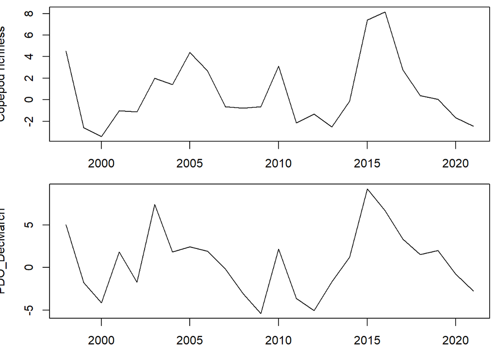

```r
par(mfrow = c(2,1), mai = c(0.5, 0.7, 0.1, 0.1), omi = c(0, 0, 0, 0))
plot(seq(1998,2021),subset_data["Copepod_richness",], type = "l", xlab = "years", ylab ="Copepod richness")
plot(seq(1998,2021),subset_data["PDO_DecMarch",], type = "l", xlab = "years", ylab ="PDO_DecMarch")
```

# General tasks

Each group has the same general tasks, but you will adapt them as you work on the data.

Please pick a type of indicators, and develop a 2- or 3-state multivariate HMM.

# Methods

A few tips:

- Assume all responses are Gaussian.
- You’re welcome to include covariates (year? Climate variables?) – but fitting a simple model without covariates is also totally fine

```r
library(depmixS4)
data <- data.frame(t(subset_data))
fitmod <- depmix(Copepod_richness ~1,
                 nstates = 2,
                 transition = ~ 1,
                 family = gaussian(),
                 data = data)
```

```r
set.seed(123)
fit1 <- fit(fitmod)
```

```
## converged at iteration 18 with logLik: -54.68034
```

```r
pars <- getpars(fit1)
matrix(pars[3:6], 2, 2, byrow = TRUE)
```

```
##           [,1]      [,2]
## [1,] 0.7536262 0.2463738
## [2,] 0.4021802 0.5978198
```

```r
AIC1 <- AIC(fitmod)
```

```r
fitmod_cov <- depmix(Copepod_richness ~1 + PDO_DecMarch,
                 nstates = 2,
                 transition = ~ 1,
                 family = gaussian(),
                 data = data)
```

```r
set.seed(123)
fit_cov <- fit(fitmod_cov)
```

```
## converged at iteration 40 with logLik: -41.20702
```

```r
pars_cov <- getpars(fit_cov)
matrix(pars_cov[3:6], 2, 2, byrow = TRUE)
```

```
##           [,1]      [,2]
## [1,] 0.4533026 0.5466974
## [2,] 0.3606362 0.6393638
```

```r
AIC_cov <- AIC(fitmod_cov)
```

## Multivariate time series

```r
rownames(stoplight) <- stoplight[,1]

subset_data <- stoplight[c("Copepod_richness","N_copepod","S_copepod","PDO_DecMarch"),3:26]

#column names should be years
colnames(subset_data) <- seq(1998,2021)

print(subset_data)
```

```
##                   1998  1999  2000  2001  2002  2003 2004  2005  2006  2007
## Copepod_richness  4.54 -2.58 -3.41 -1.03 -1.12  1.99 1.42  4.39  2.68 -0.63
## N_copepod        -0.76  0.04  0.15  0.15  0.29 -0.13 0.05 -0.85 -0.01  0.14
## S_copepod         0.60 -0.23 -0.21 -0.22 -0.23  0.09 0.20  0.55  0.07 -0.07
## PDO_DecMarch      5.07 -1.75 -4.17  1.86 -1.73  7.45 1.85  2.44  1.94 -0.17
##                   2008  2009 2010  2011  2012  2013  2014  2015  2016  2017
## Copepod_richness -0.76 -0.65 3.12 -2.13 -1.31 -2.51 -0.11  7.42  8.15  2.79
## N_copepod         0.26  0.15 0.16  0.44  0.39  0.28  0.26 -0.28 -0.89 -0.63
## S_copepod        -0.23 -0.19 0.21 -0.14 -0.19 -0.20 -0.02  0.41  0.50  0.31
## PDO_DecMarch     -3.06 -5.41 2.17 -3.65 -5.07 -1.67  1.24  9.26  6.69  3.38
##                  2018 2019  2020  2021
## Copepod_richness 0.39 0.05 -1.68 -2.45
## N_copepod        0.22 0.40  0.48  0.56
## S_copepod        0.00 0.12 -0.15 -0.22
## PDO_DecMarch     1.52 2.01 -0.76 -2.77
```

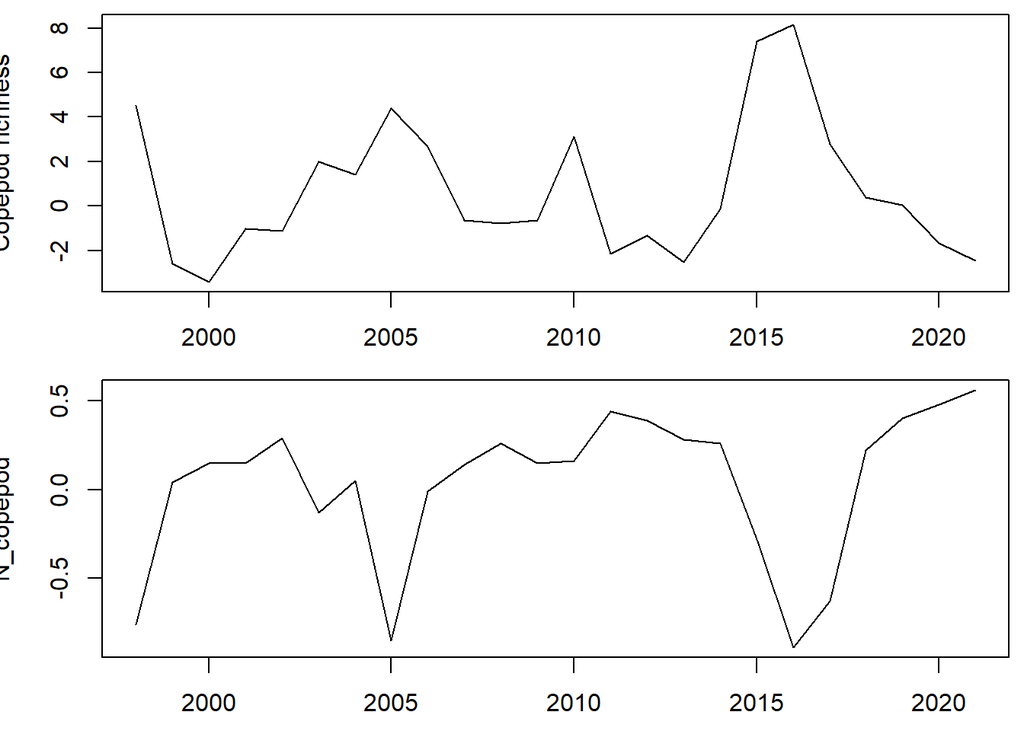

```r
par(mfrow = c(2,1), mai = c(0.5, 0.7, 0.1, 0.1), omi = c(0, 0, 0, 0))
plot(seq(1998,2021),subset_data["Copepod_richness",], type = "l", xlab = "years", ylab ="Copepod richness")
plot(seq(1998,2021),subset_data["N_copepod",], type = "l", xlab = "years", ylab ="N_copepod")
```

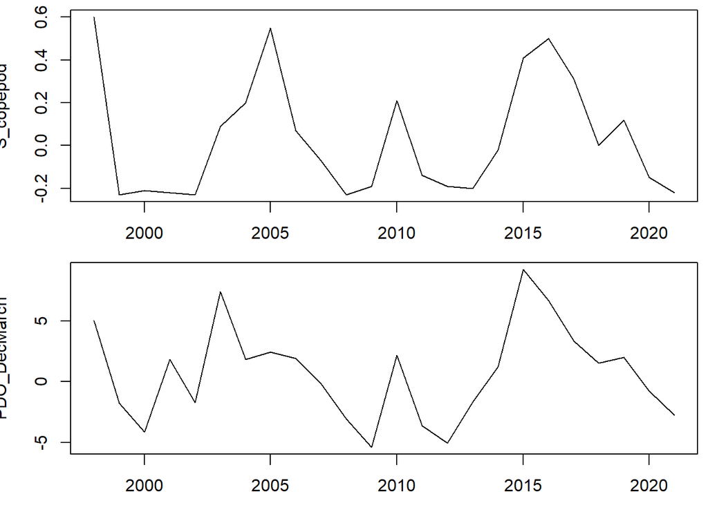

```r
plot(seq(1998,2021),subset_data["S_copepod",], type = "l", xlab = "years", ylab ="S_copepod")
plot(seq(1998,2021),subset_data["PDO_DecMarch",], type = "l", xlab = "years", ylab ="PDO_DecMarch")
```

```r
library(tidyverse)
subset_data_l <- subset_data
subset_data_l$ID <- rownames(subset_data_l)

subset_data_long <- subset_data_l %>%
  pivot_longer(!ID, names_to = "variable",
               values_to = "value")


subset_multi <-pivot_wider(subset_data_long, names_from = ID, values_from = value, names_repair = "check_unique")
```